# individual-crab-genes-over-time

Rmd to get genes that change over time within individual crab RNA seq.

Will start by making heatmaps of top genes (based on a cut-off threshold that `pheatmap` can handle in terms of number of rows) and then pull out the clusters of genes, and annotate.

Using count data from transcriptome v 3.1.

### Load packages:

```r
library(dplyr)
library(tidyverse)
```

```r
library(pheatmap)
library(data.table)
library(RColorBrewer)
```

### Load in data of counts from individual crab RNAseq (transcriptome v 3.1):

```r
norm_counts <- read.delim("../data/salmon.isoform.TMM.EXPR.matrix")
head(norm_counts)
```

```
##                          X X294_quant X254_quant X280_quant X485_quant
## 1  TRINITY_DN5772_c0_g1_i1      0.000      0.000      0.000      0.000
## 2  TRINITY_DN2201_c0_g1_i1      0.406      0.000      1.537      0.000
## 3  TRINITY_DN4656_c0_g1_i1      2.445      7.675      1.673      3.277
## 4  TRINITY_DN7591_c0_g1_i1      3.369      1.049      1.366      0.444
## 5  TRINITY_DN6285_c0_g1_i4      0.000      0.000      0.000      1.806
## 6 TRINITY_DN28918_c0_g1_i1      0.000      0.000      0.000      0.000
##   X481_quant X173_quant X222_quant X151_quant X272_quant X132_quant X127_quant
## 1      0.000      0.000      0.000      0.000          0       0.00      0.000
## 2      0.000      0.000      0.817      0.000          0       0.00      0.000
## 3      2.057     28.523      2.074      4.561          0       2.39      2.925
## 4      6.289      0.000      4.666      2.383          0       0.00     10.800
## 5      0.000      0.000      0.000      0.000          0       0.00      0.000
## 6      1.520      0.000      0.000      0.000          0       0.00      0.919
##   X73_quant X427_quant X118_quant X334_quant X349_quant X425_quant X178_quant
## 1         0          0      0.000      0.000          0          0      0.000
## 2         0          0      0.000      0.000          0          0      0.000
## 3         0          0      2.047      1.627          0          0      6.384
## 4         0          0      1.650      0.000          0          0      0.839
## 5         0          0      0.000      0.000          0          0      0.000
## 6         0          0      0.000      0.000          0          0      1.990
##   X72_quant X463_quant X221_quant X445_quant X359_quant X113_quant
## 1     0.000          0          0      0.000      1.976      0.000
## 2     0.000          0          0      7.232      0.000      2.599
## 3     2.853          0          0      2.853      4.987      2.019
## 4     0.000          0          0      8.787      5.773      8.427
## 5     0.000          0          0      1.397      0.000      0.000
## 6     0.000          0          0      0.000      0.000      0.000
```

Set Trinity_ID as row names:

```r
rownames(norm_counts) <- norm_counts$X #set Trinity IDs as rownames
norm_counts <- norm_counts[,-1] #remove redundant column
head(norm_counts)
```

```
##                          X294_quant X254_quant X280_quant X485_quant X481_quant
## TRINITY_DN5772_c0_g1_i1       0.000      0.000      0.000      0.000      0.000
## TRINITY_DN2201_c0_g1_i1       0.406      0.000      1.537      0.000      0.000
## TRINITY_DN4656_c0_g1_i1       2.445      7.675      1.673      3.277      2.057
## TRINITY_DN7591_c0_g1_i1       3.369      1.049      1.366      0.444      6.289
## TRINITY_DN6285_c0_g1_i4       0.000      0.000      0.000      1.806      0.000
## TRINITY_DN28918_c0_g1_i1      0.000      0.000      0.000      0.000      1.520
##                          X173_quant X222_quant X151_quant X272_quant X132_quant
## TRINITY_DN5772_c0_g1_i1       0.000      0.000      0.000          0       0.00
## TRINITY_DN2201_c0_g1_i1       0.000      0.817      0.000          0       0.00
## TRINITY_DN4656_c0_g1_i1      28.523      2.074      4.561          0       2.39
## TRINITY_DN7591_c0_g1_i1       0.000      4.666      2.383          0       0.00
## TRINITY_DN6285_c0_g1_i4       0.000      0.000      0.000          0       0.00
## TRINITY_DN28918_c0_g1_i1      0.000      0.000      0.000          0       0.00
##                          X127_quant X73_quant X427_quant X118_quant X334_quant
## TRINITY_DN5772_c0_g1_i1       0.000         0          0      0.000      0.000
## TRINITY_DN2201_c0_g1_i1       0.000         0          0      0.000      0.000
## TRINITY_DN4656_c0_g1_i1       2.925         0          0      2.047      1.627
## TRINITY_DN7591_c0_g1_i1      10.800         0          0      1.650      0.000
## TRINITY_DN6285_c0_g1_i4       0.000         0          0      0.000      0.000
## TRINITY_DN28918_c0_g1_i1      0.919         0          0      0.000      0.000
##                          X349_quant X425_quant X178_quant X72_quant X463_quant
## TRINITY_DN5772_c0_g1_i1           0          0      0.000     0.000          0
## TRINITY_DN2201_c0_g1_i1           0          0      0.000     0.000          0
## TRINITY_DN4656_c0_g1_i1           0          0      6.384     2.853          0
## TRINITY_DN7591_c0_g1_i1           0          0      0.839     0.000          0
## TRINITY_DN6285_c0_g1_i4           0          0      0.000     0.000          0
## TRINITY_DN28918_c0_g1_i1          0          0      1.990     0.000          0
##                          X221_quant X445_quant X359_quant X113_quant
## TRINITY_DN5772_c0_g1_i1           0      0.000      1.976      0.000
## TRINITY_DN2201_c0_g1_i1           0      7.232      0.000      2.599
## TRINITY_DN4656_c0_g1_i1           0      2.853      4.987      2.019
## TRINITY_DN7591_c0_g1_i1           0      8.787      5.773      8.427
## TRINITY_DN6285_c0_g1_i4           0      1.397      0.000      0.000
## TRINITY_DN28918_c0_g1_i1          0      0.000      0.000      0.000
```

ROUND INTEGERS UP:

```r
norm_counts <- round(norm_counts,0)
head(norm_counts)
```

```
##                          X294_quant X254_quant X280_quant X485_quant X481_quant
## TRINITY_DN5772_c0_g1_i1           0          0          0          0          0
## TRINITY_DN2201_c0_g1_i1           0          0          2          0          0
## TRINITY_DN4656_c0_g1_i1           2          8          2          3          2
## TRINITY_DN7591_c0_g1_i1           3          1          1          0          6
## TRINITY_DN6285_c0_g1_i4           0          0          0          2          0
## TRINITY_DN28918_c0_g1_i1          0          0          0          0          2
##                          X173_quant X222_quant X151_quant X272_quant X132_quant
## TRINITY_DN5772_c0_g1_i1           0          0          0          0          0
## TRINITY_DN2201_c0_g1_i1           0          1          0          0          0
## TRINITY_DN4656_c0_g1_i1          29          2          5          0          2
## TRINITY_DN7591_c0_g1_i1           0          5          2          0          0
## TRINITY_DN6285_c0_g1_i4           0          0          0          0          0
## TRINITY_DN28918_c0_g1_i1          0          0          0          0          0
##                          X127_quant X73_quant X427_quant X118_quant X334_quant
## TRINITY_DN5772_c0_g1_i1           0         0          0          0          0
## TRINITY_DN2201_c0_g1_i1           0         0          0          0          0
## TRINITY_DN4656_c0_g1_i1           3         0          0          2          2
## TRINITY_DN7591_c0_g1_i1          11         0          0          2          0
## TRINITY_DN6285_c0_g1_i4           0         0          0          0          0
## TRINITY_DN28918_c0_g1_i1          1         0          0          0          0
##                          X349_quant X425_quant X178_quant X72_quant X463_quant
## TRINITY_DN5772_c0_g1_i1           0          0          0         0          0
## TRINITY_DN2201_c0_g1_i1           0          0          0         0          0
## TRINITY_DN4656_c0_g1_i1           0          0          6         3          0
## TRINITY_DN7591_c0_g1_i1           0          0          1         0          0
## TRINITY_DN6285_c0_g1_i4           0          0          0         0          0
## TRINITY_DN28918_c0_g1_i1          0          0          2         0          0
##                          X221_quant X445_quant X359_quant X113_quant
## TRINITY_DN5772_c0_g1_i1           0          0          2          0
## TRINITY_DN2201_c0_g1_i1           0          7          0          3
## TRINITY_DN4656_c0_g1_i1           0          3          5          2
## TRINITY_DN7591_c0_g1_i1           0          9          6          8
## TRINITY_DN6285_c0_g1_i4           0          1          0          0
## TRINITY_DN28918_c0_g1_i1          0          0          0          0
```

Set rownames as a column again:

```r
norm_counts <- tibble::rownames_to_column(norm_counts, "Trinity_ID")
head(norm_counts)
```

```
##                 Trinity_ID X294_quant X254_quant X280_quant X485_quant
## 1  TRINITY_DN5772_c0_g1_i1          0          0          0          0
## 2  TRINITY_DN2201_c0_g1_i1          0          0          2          0
## 3  TRINITY_DN4656_c0_g1_i1          2          8          2          3
## 4  TRINITY_DN7591_c0_g1_i1          3          1          1          0
## 5  TRINITY_DN6285_c0_g1_i4          0          0          0          2
## 6 TRINITY_DN28918_c0_g1_i1          0          0          0          0
##   X481_quant X173_quant X222_quant X151_quant X272_quant X132_quant X127_quant
## 1          0          0          0          0          0          0          0
## 2          0          0          1          0          0          0          0
## 3          2         29          2          5          0          2          3
## 4          6          0          5          2          0          0         11
## 5          0          0          0          0          0          0          0
## 6          2          0          0          0          0          0          1
##   X73_quant X427_quant X118_quant X334_quant X349_quant X425_quant X178_quant
## 1         0          0          0          0          0          0          0
## 2         0          0          0          0          0          0          0
## 3         0          0          2          2          0          0          6
## 4         0          0          2          0          0          0          1
## 5         0          0          0          0          0          0          0
## 6         0          0          0          0          0          0          2
##   X72_quant X463_quant X221_quant X445_quant X359_quant X113_quant
## 1         0          0          0          0          2          0
## 2         0          0          0          7          0          3
## 3         3          0          0          3          5          2
## 4         0          0          0          9          6          8
## 5         0          0          0          1          0          0
## 6         0          0          0          0          0          0
```

Rename sample columns:

```r
colnames(norm_counts) <- c("Trinity_ID", "CrabH_2", "CrabE_2", "CrabI_2", "CrabC_17", "CrabB_17", "CrabG_0", "CrabF_2", "CrabE_0", "CrabG_2", "CrabC_0", "CrabI_0", "CrabD_0", "CrabD_17", "CrabB_0", "CrabC_2", "CrabB_2", "CrabF_17", "CrabA_0", "CrabH_0", "CrabA_17", "CrabD_2", "CrabE_17", "CrabA_2", "CrabF_0")
head(norm_counts)
```

```
##                 Trinity_ID CrabH_2 CrabE_2 CrabI_2 CrabC_17 CrabB_17 CrabG_0
## 1  TRINITY_DN5772_c0_g1_i1       0       0       0        0        0       0
## 2  TRINITY_DN2201_c0_g1_i1       0       0       2        0        0       0
## 3  TRINITY_DN4656_c0_g1_i1       2       8       2        3        2      29
## 4  TRINITY_DN7591_c0_g1_i1       3       1       1        0        6       0
## 5  TRINITY_DN6285_c0_g1_i4       0       0       0        2        0       0
## 6 TRINITY_DN28918_c0_g1_i1       0       0       0        0        2       0
##   CrabF_2 CrabE_0 CrabG_2 CrabC_0 CrabI_0 CrabD_0 CrabD_17 CrabB_0 CrabC_2
## 1       0       0       0       0       0       0        0       0       0
## 2       1       0       0       0       0       0        0       0       0
## 3       2       5       0       2       3       0        0       2       2
## 4       5       2       0       0      11       0        0       2       0
## 5       0       0       0       0       0       0        0       0       0
## 6       0       0       0       0       1       0        0       0       0
##   CrabB_2 CrabF_17 CrabA_0 CrabH_0 CrabA_17 CrabD_2 CrabE_17 CrabA_2 CrabF_0
## 1       0        0       0       0        0       0        0       2       0
## 2       0        0       0       0        0       0        7       0       3
## 3       0        0       6       3        0       0        3       5       2
## 4       0        0       1       0        0       0        9       6       8
## 5       0        0       0       0        0       0        1       0       0
## 6       0        0       2       0        0       0        0       0       0
```

### Subset samples from 1 crab (crab A)

```r
crabA <- select(norm_counts, "Trinity_ID", "CrabA_0", "CrabA_2", "CrabA_17")
head(crabA)
```

```
##                 Trinity_ID CrabA_0 CrabA_2 CrabA_17
## 1  TRINITY_DN5772_c0_g1_i1       0       2        0
## 2  TRINITY_DN2201_c0_g1_i1       0       0        0
## 3  TRINITY_DN4656_c0_g1_i1       6       5        0
## 4  TRINITY_DN7591_c0_g1_i1       1       6        0
## 5  TRINITY_DN6285_c0_g1_i4       0       0        0
## 6 TRINITY_DN28918_c0_g1_i1       2       0        0
```

Wayyyy too many genes for a heatmap. Filter out rows that have 0 across all three timepoints:

```r
crabA <- crabA[rowSums(crabA[, -1] >0) !=0, ]
head(crabA)
```

```
##                  Trinity_ID CrabA_0 CrabA_2 CrabA_17
## 1   TRINITY_DN5772_c0_g1_i1       0       2        0
## 3   TRINITY_DN4656_c0_g1_i1       6       5        0
## 4   TRINITY_DN7591_c0_g1_i1       1       6        0
## 6  TRINITY_DN28918_c0_g1_i1       2       0        0
## 10  TRINITY_DN4992_c0_g1_i2       0       2        0
## 13 TRINITY_DN10774_c0_g1_i3       6      12        0
```

Now there’s 16,427 genes

Now lets remove low-count genes. Say, remove rows where counts across the three samples is less than 10. Sum all rows in new column:

```r
crabA$sums <- rowSums( crabA[,2:4] )
head(crabA)
```

```
##                  Trinity_ID CrabA_0 CrabA_2 CrabA_17 sums
## 1   TRINITY_DN5772_c0_g1_i1       0       2        0    2
## 3   TRINITY_DN4656_c0_g1_i1       6       5        0   11
## 4   TRINITY_DN7591_c0_g1_i1       1       6        0    7
## 6  TRINITY_DN28918_c0_g1_i1       2       0        0    2
## 10  TRINITY_DN4992_c0_g1_i2       0       2        0    2
## 13 TRINITY_DN10774_c0_g1_i3       6      12        0   18
```

Remove columns with sums <= 30 –> didn’t work. too many rows (3,504). I troubleshooted until coming to the number 55 - 2668 rows, and heatmap worked

```r
crabA_highcts <- filter(crabA, sums >= 55)
head(crabA_highcts)
```

```
##                 Trinity_ID CrabA_0 CrabA_2 CrabA_17 sums
## 1 TRINITY_DN13394_c0_g1_i1      54      84        0  138
## 2 TRINITY_DN26808_c0_g1_i1      63     136        0  199
## 3    TRINITY_DN80_c0_g1_i1     130     230        0  360
## 4  TRINITY_DN3401_c0_g1_i1      71      90        0  161
## 5  TRINITY_DN1879_c0_g1_i1      22      35        0   57
## 6  TRINITY_DN1705_c0_g1_i3      70      62        0  132
```

Now there’s 2,668 rows

### Make a heatmap of the list of 2668 genes:

Need to remove the “sums” column for heatmap:

```r
crabA_heatmap <- select(crabA_highcts, "Trinity_ID", "CrabA_0", "CrabA_2", "CrabA_17")
head(crabA_heatmap)
```

```
##                 Trinity_ID CrabA_0 CrabA_2 CrabA_17
## 1 TRINITY_DN13394_c0_g1_i1      54      84        0
## 2 TRINITY_DN26808_c0_g1_i1      63     136        0
## 3    TRINITY_DN80_c0_g1_i1     130     230        0
## 4  TRINITY_DN3401_c0_g1_i1      71      90        0
## 5  TRINITY_DN1879_c0_g1_i1      22      35        0
## 6  TRINITY_DN1705_c0_g1_i3      70      62        0
```

Have to make trinity ID column into rownames: Set Trinity_ID as row names:

```r
rownames(crabA_heatmap) <- crabA_heatmap$Trinity_ID #set Trinity IDs as rownames
crabA_heatmap <- crabA_heatmap[,-1] #remove redundant column
head(crabA_heatmap)
```

```
##                          CrabA_0 CrabA_2 CrabA_17
## TRINITY_DN13394_c0_g1_i1      54      84        0
## TRINITY_DN26808_c0_g1_i1      63     136        0
## TRINITY_DN80_c0_g1_i1        130     230        0
## TRINITY_DN3401_c0_g1_i1       71      90        0
## TRINITY_DN1879_c0_g1_i1       22      35        0
## TRINITY_DN1705_c0_g1_i3       70      62        0
```

Create heatmap colors:

```r
heatmapPurOr <- RColorBrewer::brewer.pal(11, "PuOr")
```

```r
heatmapRdGy <- RColorBrewer::brewer.pal(11, "RdGy")
```

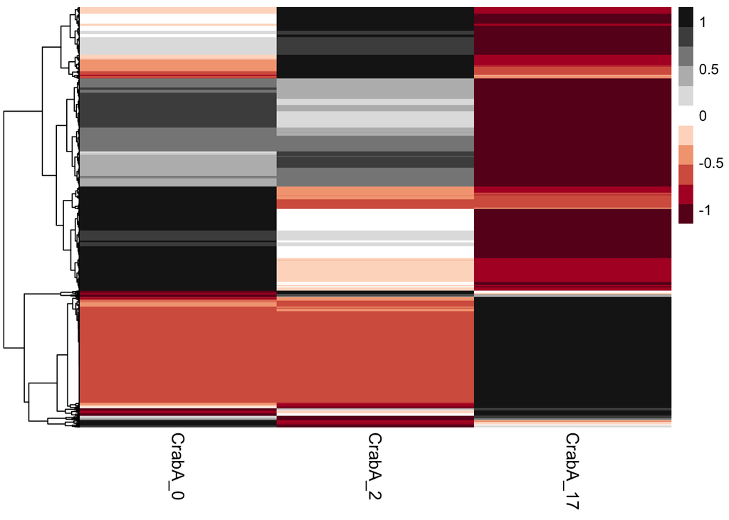

```r
pheatmap(crabA_heatmap, scale = "row", cluster_row = TRUE, cluster_cols = FALSE, clustering_distance_rows = "euclidean", clustering_method = "average", show_rownames = FALSE, show_colnames = TRUE, treeheight_col = 80, legend = TRUE, color = heatmapRdGy, fontsize_col = 12, fontsize_row = 12)
```

Goal: pull out clusters of genes and describe and annotate. For example, cluster 1 –> in crab A goes zero, up, down over time. Then describe those genes (`join` with BLAST output from transcriptome v 3.1 and uniprot-sprot database info.)

### Get genes in those clusters that change over time:

Set heatmap as an object:

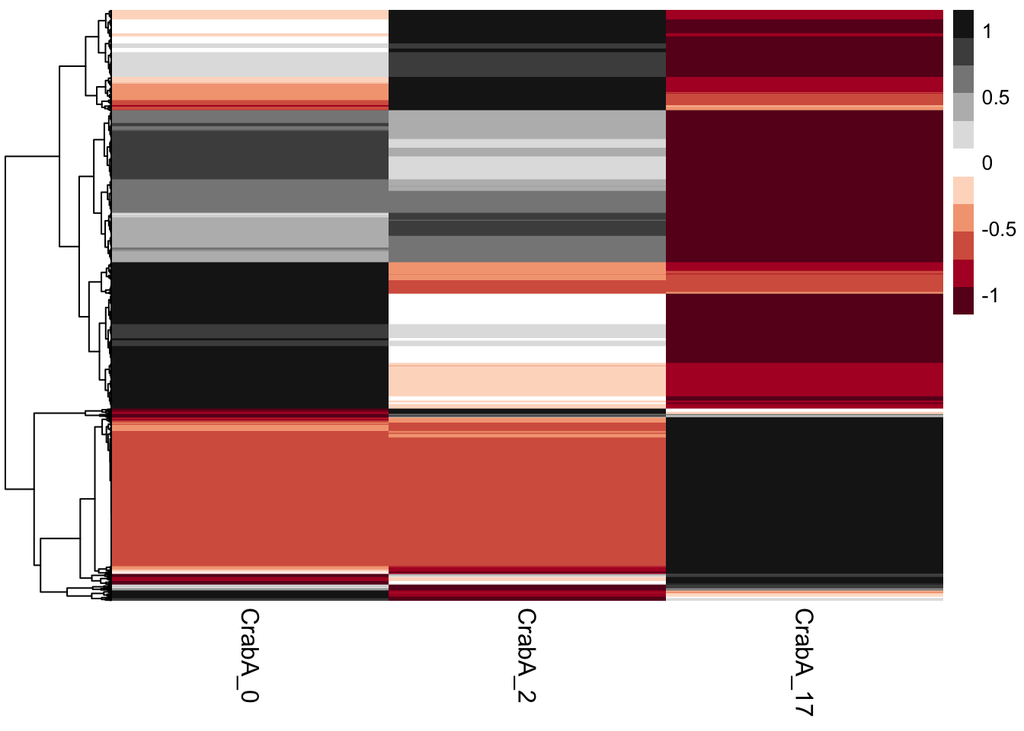

```r
Aheatmap <- pheatmap(crabA_heatmap, scale = "row", cluster_row = TRUE, cluster_cols = FALSE, clustering_distance_rows = "euclidean", clustering_method = "average", show_rownames = FALSE, show_colnames = TRUE, treeheight_col = 80, legend = TRUE, color = heatmapRdGy, fontsize_col = 12, fontsize_row = 12)
```

Extract clusters from the heatmap.

```r
CrabA.clust <- cbind(crabA_heatmap,
                   cluster = cutree(Aheatmap$tree_row,
                                     k = 8))
head(CrabA.clust)
```

```
##                          CrabA_0 CrabA_2 CrabA_17 cluster
## TRINITY_DN13394_c0_g1_i1      54      84        0       1
## TRINITY_DN26808_c0_g1_i1      63     136        0       1
## TRINITY_DN80_c0_g1_i1        130     230        0       1
## TRINITY_DN3401_c0_g1_i1       71      90        0       2
## TRINITY_DN1879_c0_g1_i1       22      35        0       1
## TRINITY_DN1705_c0_g1_i3       70      62        0       2
```

pull out just cluster column:

```r
clusters <- select(CrabA.clust, "cluster")
head(clusters)
```

```
##                          cluster
## TRINITY_DN13394_c0_g1_i1       1
## TRINITY_DN26808_c0_g1_i1       1
## TRINITY_DN80_c0_g1_i1          1
## TRINITY_DN3401_c0_g1_i1        2
## TRINITY_DN1879_c0_g1_i1        1
## TRINITY_DN1705_c0_g1_i3        2
```

Rename the clusters in the rows to “cluster #” instead of just the number.

```r
clusters <- data.frame(cluster = ifelse(clusters == 1, "cluster 1", ifelse(clusters == 2, "cluster 2", ifelse(clusters == 3, "cluster 3", ifelse(clusters ==4, "cluster 4", ifelse(clusters == 5, "cluster 5", ifelse(clusters == 6, "cluster 6", ifelse(clusters == 7, "cluster 7", "cluster 8"))))))))
head(clusters)
```

```
##                            cluster
## TRINITY_DN13394_c0_g1_i1 cluster 1
## TRINITY_DN26808_c0_g1_i1 cluster 1
## TRINITY_DN80_c0_g1_i1    cluster 1
## TRINITY_DN3401_c0_g1_i1  cluster 2
## TRINITY_DN1879_c0_g1_i1  cluster 1
## TRINITY_DN1705_c0_g1_i3  cluster 2
```

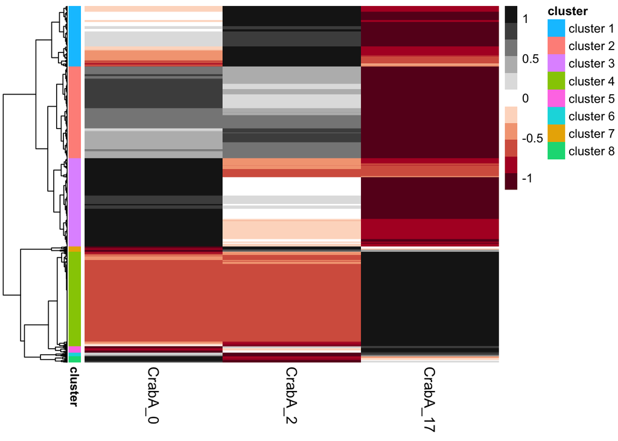

```r
pheatmap(crabA_heatmap, scale = "row", cluster_row = TRUE, cluster_cols = FALSE, clustering_distance_rows = "euclidean", clustering_method = "average", annotation_row = clusters, show_rownames = FALSE, show_colnames = TRUE, treeheight_col = 80, legend = TRUE, color = heatmapRdGy, fontsize_col = 12, fontsize_row = 12)
```

### `join` sample count data for Crab A with transcriptome v 3.1 `blast` output and uniprot-sp-GO info, and keep the column of cluster labels. Write out to analyses.

CrabA.clust –> heatmap counts with Trinity IDs as row names with cluster numbers.

Read in transcriptome v 3.1 `blast` output:  
(_blast-sep-v3.1.tab: separates out the pipes and tabs- better to `join` with)

```r
blast <- read.delim("../analyses/_blast-sep-v3.1.tab", header = FALSE)
head(blast)
```

```
##                        V1 V2     V3          V4   V5  V6  V7 V8  V9  V10 V11
## 1 TRINITY_DN5604_c0_g2_i1 sp B0KTG8  TRI1_PSEPG 30.0 360 168 12 279 1319  56
## 2   TRINITY_DN9_c4_g1_i10 sp Q3SWW9  PP1B_BOVIN 91.8 184  15  0   2  553 134
## 3    TRINITY_DN9_c4_g1_i9 sp Q3SWW9  PP1B_BOVIN 91.8 184  15  0   2  553 134
## 4   TRINITY_DN38_c0_g3_i1 sp P42867   GPT_MOUSE 43.8 432 205  7 135 1412  11
## 5   TRINITY_DN81_c0_g1_i9 sp Q91X83 METK1_MOUSE 48.8 377 188  2  89 1207  19
## 6   TRINITY_DN81_c0_g1_i4 sp Q91X83 METK1_MOUSE 48.8 377 188  2  89 1207  19
##   V12      V13   V14
## 1 344  2.3e-28 129.0
## 2 317 1.0e-102 374.8
## 3 317 1.0e-102 374.8
## 4 410  2.9e-92 341.3
## 5 394 2.5e-102 374.0
## 6 394 3.0e-102 374.0
```

Rename first and third column:

```r
colnames(blast) <- c("Trinity_ID", "V2", "uniprot_acc_ID", "V4", "V5", "V6", "V7", "V8", "V9", "V10", "V11", "V12", "V13", "V14")
head(blast)
```

```
##                Trinity_ID V2 uniprot_acc_ID          V4   V5  V6  V7 V8  V9
## 1 TRINITY_DN5604_c0_g2_i1 sp         B0KTG8  TRI1_PSEPG 30.0 360 168 12 279
## 2   TRINITY_DN9_c4_g1_i10 sp         Q3SWW9  PP1B_BOVIN 91.8 184  15  0   2
## 3    TRINITY_DN9_c4_g1_i9 sp         Q3SWW9  PP1B_BOVIN 91.8 184  15  0   2
## 4   TRINITY_DN38_c0_g3_i1 sp         P42867   GPT_MOUSE 43.8 432 205  7 135
## 5   TRINITY_DN81_c0_g1_i9 sp         Q91X83 METK1_MOUSE 48.8 377 188  2  89
## 6   TRINITY_DN81_c0_g1_i4 sp         Q91X83 METK1_MOUSE 48.8 377 188  2  89
##    V10 V11 V12      V13   V14
## 1 1319  56 344  2.3e-28 129.0
## 2  553 134 317 1.0e-102 374.8
## 3  553 134 317 1.0e-102 374.8
## 4 1412  11 410  2.9e-92 341.3
## 5 1207  19 394 2.5e-102 374.0
## 6 1207  19 394 3.0e-102 374.0
```

Read in uniprot-SP-GO file

```r
uniprot_SP_GO <- read.delim("http://owl.fish.washington.edu/halfshell/bu-alanine-wd/17-07-20/uniprot-SP-GO.sorted", sep = '\t', header = FALSE)
head(uniprot_SP_GO)
```

```
##           V1          V2       V3
## 1 A0A023GPI8  LECA_CANBL reviewed
## 2 A0A023GPJ0  CDII_ENTCC reviewed
## 3 A0A023PXA5 YA19A_YEAST reviewed
## 4 A0A023PXB0 YA019_YEAST reviewed
## 5 A0A023PXB5  IRC2_YEAST reviewed
## 6 A0A023PXB9 YD99W_YEAST reviewed
##                                                                                           V4
## 1            Lectin alpha chain (CboL) [Cleaved into: Lectin beta chain; Lectin gamma chain]
## 2                                                                      Immunity protein CdiI
## 3                                                 Putative uncharacterized protein YAL019W-A
## 4                                                 Putative uncharacterized protein YAR019W-A
## 5 Putative uncharacterized membrane protein IRC2 (Increased recombination centers protein 2)
## 6                                          Putative uncharacterized membrane protein YDR199W
##                 V5
## 1
## 2 cdiI ECL_04450.1
## 3        YAL019W-A
## 4        YAR019W-A
## 5     IRC2 YDR112W
## 6          YDR199W
##                                                                                               V6
## 1                                                                            Canavalia boliviana
## 2 Enterobacter cloacae subsp. cloacae (strain ATCC 13047 / DSM 30054 / NBRC 13535 / NCDC 279-56)
## 3                          Saccharomyces cerevisiae (strain ATCC 204508 / S288c) (Baker's yeast)
## 4                          Saccharomyces cerevisiae (strain ATCC 204508 / S288c) (Baker's yeast)
## 5                          Saccharomyces cerevisiae (strain ATCC 204508 / S288c) (Baker's yeast)
## 6                          Saccharomyces cerevisiae (strain ATCC 204508 / S288c) (Baker's yeast)
##    V7 V8                                          V9
## 1 237
## 2 145
## 3 189
## 4 110
## 5 102    integral component of membrane [GO:0016021]
## 6 121    integral component of membrane [GO:0016021]
##                                                            V10
## 1 mannose binding [GO:0005537]; metal ion binding [GO:0046872]
## 2
## 3
## 4
## 5
## 6
##                                                            V11
## 1 mannose binding [GO:0005537]; metal ion binding [GO:0046872]
## 2
## 3
## 4
## 5                  integral component of membrane [GO:0016021]
## 6                  integral component of membrane [GO:0016021]
##                      V12
## 1 GO:0005537; GO:0046872
## 2
## 3
## 4
## 5             GO:0016021
## 6             GO:0016021
```

Rename columns:

```r
colnames(uniprot_SP_GO) <- c("uniprot_acc_ID", "V2", "V3", "V4", "V5", "V6", "V7", "V8", "V9", "V10", "V11", "V12")
head(uniprot_SP_GO)
```

```
##   uniprot_acc_ID          V2       V3
## 1     A0A023GPI8  LECA_CANBL reviewed
## 2     A0A023GPJ0  CDII_ENTCC reviewed
## 3     A0A023PXA5 YA19A_YEAST reviewed
## 4     A0A023PXB0 YA019_YEAST reviewed
## 5     A0A023PXB5  IRC2_YEAST reviewed
## 6     A0A023PXB9 YD99W_YEAST reviewed
##                                                                                           V4
## 1            Lectin alpha chain (CboL) [Cleaved into: Lectin beta chain; Lectin gamma chain]
## 2                                                                      Immunity protein CdiI
## 3                                                 Putative uncharacterized protein YAL019W-A
## 4                                                 Putative uncharacterized protein YAR019W-A
## 5 Putative uncharacterized membrane protein IRC2 (Increased recombination centers protein 2)
## 6                                          Putative uncharacterized membrane protein YDR199W
##                 V5
## 1
## 2 cdiI ECL_04450.1
## 3        YAL019W-A
## 4        YAR019W-A
## 5     IRC2 YDR112W
## 6          YDR199W
##                                                                                               V6
## 1                                                                            Canavalia boliviana
## 2 Enterobacter cloacae subsp. cloacae (strain ATCC 13047 / DSM 30054 / NBRC 13535 / NCDC 279-56)
## 3                          Saccharomyces cerevisiae (strain ATCC 204508 / S288c) (Baker's yeast)
## 4                          Saccharomyces cerevisiae (strain ATCC 204508 / S288c) (Baker's yeast)
## 5                          Saccharomyces cerevisiae (strain ATCC 204508 / S288c) (Baker's yeast)
## 6                          Saccharomyces cerevisiae (strain ATCC 204508 / S288c) (Baker's yeast)
##    V7 V8                                          V9
## 1 237
## 2 145
## 3 189
## 4 110
## 5 102    integral component of membrane [GO:0016021]
## 6 121    integral component of membrane [GO:0016021]
##                                                            V10
## 1 mannose binding [GO:0005537]; metal ion binding [GO:0046872]
## 2
## 3
## 4
## 5
## 6
##                                                            V11
## 1 mannose binding [GO:0005537]; metal ion binding [GO:0046872]
## 2
## 3
## 4
## 5                  integral component of membrane [GO:0016021]
## 6                  integral component of membrane [GO:0016021]
##                      V12
## 1 GO:0005537; GO:0046872
## 2
## 3
## 4
## 5             GO:0016021
## 6             GO:0016021
```

`join` blast output and uniprot-SP-GO:

```r
blastGO <- left_join(blast, uniprot_SP_GO, by = "uniprot_acc_ID")
head(blastGO)
```

```
##                Trinity_ID V2.x uniprot_acc_ID        V4.x V5.x V6.x V7.x V8.x
## 1 TRINITY_DN5604_c0_g2_i1   sp         B0KTG8  TRI1_PSEPG 30.0  360  168   12
## 2   TRINITY_DN9_c4_g1_i10   sp         Q3SWW9  PP1B_BOVIN 91.8  184   15    0
## 3    TRINITY_DN9_c4_g1_i9   sp         Q3SWW9  PP1B_BOVIN 91.8  184   15    0
## 4   TRINITY_DN38_c0_g3_i1   sp         P42867   GPT_MOUSE 43.8  432  205    7
## 5   TRINITY_DN81_c0_g1_i9   sp         Q91X83 METK1_MOUSE 48.8  377  188    2
## 6   TRINITY_DN81_c0_g1_i4   sp         Q91X83 METK1_MOUSE 48.8  377  188    2
##   V9.x V10.x V11.x V12.x      V13   V14        V2.y       V3
## 1  279  1319    56   344  2.3e-28 129.0        <NA>     <NA>
## 2    2   553   134   317 1.0e-102 374.8        <NA>     <NA>
## 3    2   553   134   317 1.0e-102 374.8        <NA>     <NA>
## 4  135  1412    11   410  2.9e-92 341.3        <NA>     <NA>
## 5   89  1207    19   394 2.5e-102 374.0 METK1_MOUSE reviewed
## 6   89  1207    19   394 3.0e-102 374.0 METK1_MOUSE reviewed
##                                                                                                                       V4.y
```

[output cut: 48 more lines]

Make Trinity ID rownames into a column called “Trinity_ID” in CrabA.clust: Set Trinity_ID as row names: Set rownames as a column again:

```r
CrabA.clust <- tibble::rownames_to_column(CrabA.clust, "Trinity_ID")
head(CrabA.clust)
```

```
##                 Trinity_ID CrabA_0 CrabA_2 CrabA_17 cluster
## 1 TRINITY_DN13394_c0_g1_i1      54      84        0       1
## 2 TRINITY_DN26808_c0_g1_i1      63     136        0       1
## 3    TRINITY_DN80_c0_g1_i1     130     230        0       1
## 4  TRINITY_DN3401_c0_g1_i1      71      90        0       2
## 5  TRINITY_DN1879_c0_g1_i1      22      35        0       1
## 6  TRINITY_DN1705_c0_g1_i3      70      62        0       2
```

`join` the CrabA.clust and blastGO file based on “Trinity_ID” column:

```r
crabA.blast.GO <- left_join(CrabA.clust, blastGO, by = "Trinity_ID")
head(crabA.blast.GO)
```

```
##                 Trinity_ID CrabA_0 CrabA_2 CrabA_17 cluster V2.x uniprot_acc_ID
## 1 TRINITY_DN13394_c0_g1_i1      54      84        0       1 <NA>           <NA>
## 2 TRINITY_DN26808_c0_g1_i1      63     136        0       1 <NA>           <NA>
## 3    TRINITY_DN80_c0_g1_i1     130     230        0       1 <NA>           <NA>
## 4  TRINITY_DN3401_c0_g1_i1      71      90        0       2 <NA>           <NA>
## 5  TRINITY_DN1879_c0_g1_i1      22      35        0       1 <NA>           <NA>
## 6  TRINITY_DN1705_c0_g1_i3      70      62        0       2 <NA>           <NA>
##   V4.x V5.x V6.x V7.x V8.x V9.x V10.x V11.x V12.x V13 V14 V2.y   V3 V4.y V5.y
## 1 <NA>   NA   NA   NA   NA   NA    NA    NA    NA  NA  NA <NA> <NA> <NA> <NA>
## 2 <NA>   NA   NA   NA   NA   NA    NA    NA    NA  NA  NA <NA> <NA> <NA> <NA>
## 3 <NA>   NA   NA   NA   NA   NA    NA    NA    NA  NA  NA <NA> <NA> <NA> <NA>
## 4 <NA>   NA   NA   NA   NA   NA    NA    NA    NA  NA  NA <NA> <NA> <NA> <NA>
## 5 <NA>   NA   NA   NA   NA   NA    NA    NA    NA  NA  NA <NA> <NA> <NA> <NA>
## 6 <NA>   NA   NA   NA   NA   NA    NA    NA    NA  NA  NA <NA> <NA> <NA> <NA>
##   V6.y V7.y V8.y V9.y V10.y V11.y V12.y
## 1 <NA> <NA> <NA> <NA>  <NA>  <NA>  <NA>
## 2 <NA> <NA> <NA> <NA>  <NA>  <NA>  <NA>
## 3 <NA> <NA> <NA> <NA>  <NA>  <NA>  <NA>
## 4 <NA> <NA> <NA> <NA>  <NA>  <NA>  <NA>
## 5 <NA> <NA> <NA> <NA>  <NA>  <NA>  <NA>
## 6 <NA> <NA> <NA> <NA>  <NA>  <NA>  <NA>
```

Way too many NAs….